# Notebook 02 — Cleaning, Basic Preprocessing & Pre-Feature-Engineering EDA

This notebook prepares the raw filtered data from Notebook 01 for feature engineering.

What we do here:

- Load parquet from Notebook 01
- Create target (`default_ind`)
- Fix common dtype issues
- Remove string noise in important numeric fields
- Basic EDA (missingness, distributions, categorical frequencies, boxplots)

```python
# Imports
import warnings; warnings.filterwarnings("ignore")
import pandas as pd
import numpy as np
import matplotlib.pyplot as plt
import seaborn as sns
import os

# Show everything clearly
pd.set_option("display.max_rows", None)
pd.set_option("display.max_columns", None)

# Paths
base_path = r"C:\Users\deves\Documents\GitHub\portfolio\pdpit-lendingclub"
input_file = os.path.join(base_path, "data", "processed", "accepted_2015_to_2018_filtered.parquet")
eda_dir = os.path.join(base_path, "artifacts", "notebook02_eda")
os.makedirs(eda_dir, exist_ok=True)

print("Input file:", input_file)
print("EDA folder:", eda_dir)
```

```
Input file: C:\Users\deves\Documents\GitHub\portfolio\pdpit-lendingclub\data\processed\accepted_2015_to_2018_filtered.parquet
EDA folder: C:\Users\deves\Documents\GitHub\portfolio\pdpit-lendingclub\artifacts\notebook02_eda
```

### Load dataset

We load the parquet created in Notebook 01.  
We expect all raw LendingClub columns to be present (no column filtering happened previously).

```python
df = pd.read_parquet(input_file)
print("Loaded shape:", df.shape)
display(df.head(3))
```

```
Loaded shape: (1794323, 151)
```

|  | id | member_id | loan_amnt | funded_amnt | funded_amnt_inv | term | int_rate | installment | grade | sub_grade | emp_title | emp_length | home_ownership | annual_inc | verification_status | issue_d | loan_status | pymnt_plan | url | desc | purpose | title | zip_code | addr_state | dti | delinq_2yrs | earliest_cr_line | fico_range_low | fico_range_high | … |
| --- | --- | --- | --- | --- | --- | --- | --- | --- | --- | --- | --- | --- | --- | --- | --- | --- | --- | --- | --- | --- | --- | --- | --- | --- | --- | --- | --- | --- | --- | --- |
| 0 | 68407277 | None | 3600.0 | 3600.0 | 3600.0 | 36 months | 13.99 | 123.03 | C | C4 | leadman | 10+ years | MORTGAGE | 55000.0 | Not Verified | 2015-12-01 | Fully Paid | n | https://lendingclub.com/browse/loanDetail.acti... | None | debt_consolidation | Debt consolidation | 190xx | PA | 5.91 | 0.0 | Aug-2003 | 675.0 | 679.0 | … |
| 1 | 68355089 | None | 24700.0 | 24700.0 | 24700.0 | 36 months | 11.99 | 820.28 | C | C1 | Engineer | 10+ years | MORTGAGE | 65000.0 | Not Verified | 2015-12-01 | Fully Paid | n | https://lendingclub.com/browse/loanDetail.acti... | None | small_business | Business | 577xx | SD | 16.06 | 1.0 | Dec-1999 | 715.0 | 719.0 | … |
| 2 | 68341763 | None | 20000.0 | 20000.0 | 20000.0 | 60 months | 10.78 | 432.66 | B | B4 | truck driver | 10+ years | MORTGAGE | 63000.0 | Not Verified | 2015-12-01 | Fully Paid | n | https://lendingclub.com/browse/loanDetail.acti... | None | home_improvement | None | 605xx | IL | 10.78 | 0.0 | Aug-2000 | 695.0 | 699.0 | … |

### Create target variable: `default_ind`

Why: LendingClub uses many loan_status labels.  
We need a **binary PIT default flag**:

- 1 = Charged Off, Default, Late (>30 days)
- 0 = Fully Paid, Current, In Grace Period

This is simple and consistent with industry PIT PD setup.

```python
df["loan_status"].value_counts()
```

```
loan_status
Current               866392
Fully Paid            702191
Charged Off           192060
Late (31-120 days)     21130
In Grace Period         8235
Late (16-30 days)       4276
Default                   39
Name: count, dtype: int64
```

```python
# convert loan_status to lowercase for consistency
df["loan_status_clean"] = df["loan_status"].astype(str).str.lower()

# define bad statuses
bad_labels = ["charged off", "default", "late (31-120 days)"]

df["default_ind"] = df["loan_status_clean"].isin(bad_labels).astype("Int64")

df["default_ind"].value_counts(dropna=False)
```

```
default_ind
0    1581094
1     213229
Name: count, dtype: Int64
```

### Clean obvious string fields

Why: Some fields are numeric but stored as strings.  
We convert them using simple replacements so Feature Engineering in Notebook 03 works cleanly.

Fix:

```python
# interest rate like "13.56%"
df["int_rate"] = df["int_rate"].astype(str).str.replace("%", "", regex=False)
df["int_rate"] = pd.to_numeric(df["int_rate"], errors="coerce")
df["int_rate"].head()
```

```
0    13.99
1    11.99
2    10.78
3    14.85
4    22.45
Name: int_rate, dtype: float64
```

```python
# "36 months" → 36
df["term_clean"] = df["term"].astype(str).str.replace(" months", "", regex=False)
df["term_months"] = pd.to_numeric(df["term_clean"], errors="coerce")
df["term_months"].head()
```

```
0    36
1    36
2    60
3    60
4    60
Name: term_months, dtype: int64
```

```python
emp = df["emp_length"].astype(str)

emp = emp.str.replace("< 1 year", "0", regex=False)
emp = emp.str.replace("10+ years", "10", regex=False)
emp = emp.str.replace(" years", "", regex=False)
emp = emp.str.replace(" year", "", regex=False)
emp = emp.replace("n/a", np.nan)

df["emp_length_num"] = pd.to_numeric(emp, errors="coerce")
df["emp_length_num"].value_counts()
```

```
emp_length_num
10.0    597932
2.0     162301
0.0     153720
3.0     144155
1.0     118781
5.0     108919
4.0     108581
6.0      76514
8.0      69517
7.0      66510
9.0      61504
Name: count, dtype: int64
```

### Convert numeric-looking columns to numeric

Many columns (loan_amnt, annual_inc, dti, etc.) come as strings.  
We convert them using `pd.to_numeric`.

```python
num_cols_to_fix = [
    "loan_amnt","annual_inc","dti","delinq_2yrs","inq_last_6mths",
    "open_acc","total_acc","revol_bal","revol_util"
]

for c in num_cols_to_fix:
    df[c] = pd.to_numeric(df[c], errors="coerce")
```

### Convert dates

Convert `issue_d` to pandas datetime to make time-based EDA in Notebook 04 work properly.

```python
df["issue_d"] = pd.to_datetime(df["issue_d"], errors="coerce")
df["issue_year"] = df["issue_d"].dt.year
df["issue_month"] = df["issue_d"].dt.month
```

## EDA Step 1 — Missingness

Why: Missingness drives imputation decisions and helps us understand feature reliability.

How: Simple `.isna().sum()` and percentage.

```python
missing = df.isna().sum().to_frame("n_missing")
missing["pct_missing"] = missing["n_missing"] / len(df)
missing = missing.sort_values("pct_missing", ascending=False)

missing_file = os.path.join(eda_dir, "missingness_summary.csv")
missing.to_csv(missing_file)

print("Saved missingness summary:", missing_file)
display(missing)
```

```
Saved missingness summary: C:\Users\deves\Documents\GitHub\portfolio\pdpit-lendingclub\artifacts\notebook02_eda\missingness_summary.csv
```

|  | n_missing | pct_missing |
| --- | --- | --- |
| member_id | 1794323 | 1.000000e+00 |
| desc | 1794255 | 9.999621e-01 |
| orig_projected_additional_accrued_interest | 1786140 | 9.954395e-01 |
| deferral_term | 1783989 | 9.942407e-01 |
| hardship_length | 1783989 | 9.942407e-01 |
| hardship_loan_status | 1783989 | 9.942407e-01 |
| payment_plan_start_date | 1783989 | 9.942407e-01 |
| hardship_end_date | 1783989 | 9.942407e-01 |
| hardship_payoff_balance_amount | 1783989 | 9.942407e-01 |
| hardship_last_payment_amount | 1783989 | 9.942407e-01 |
| hardship_start_date | 1783989 | 9.942407e-01 |
| hardship_amount | 1783989 | 9.942407e-01 |
| hardship_dpd | 1783989 | 9.942407e-01 |
| hardship_status | 1783989 | 9.942407e-01 |
| hardship_reason | 1783989 | 9.942407e-01 |
| hardship_type | 1783989 | 9.942407e-01 |
| settlement_amount | 1766526 | 9.845084e-01 |
| settlement_status | 1766526 | 9.845084e-01 |
| debt_settlement_flag_date | 1766526 | 9.845084e-01 |
| settlement_percentage | 1766526 | 9.845084e-01 |
| settlement_term | 1766526 | 9.845084e-01 |
| settlement_date | 1766526 | 9.845084e-01 |
| sec_app_mths_since_last_major_derog | 1758381 | 9.799690e-01 |
| sec_app_revol_util | 1688139 | 9.408222e-01 |
| revol_bal_joint | 1686303 | 9.397990e-01 |
| sec_app_open_act_il | 1686302 | 9.397985e-01 |
| sec_app_num_rev_accts | 1686302 | 9.397985e-01 |
| sec_app_inq_last_6mths | 1686302 | 9.397985e-01 |
| sec_app_open_acc | 1686302 | 9.397985e-01 |
| sec_app_mort_acc | 1686302 | 9.397985e-01 |

[output cut: 128 more lines]

### Auto-remove very sparse columns (pct_missing > 30%)

What: identify features with more than 30% missing values (from the `missing` table already computed) and drop them from a working copy.

Why: fields with >30% missing are poor candidates to productionize (imputation risk, data pipeline fragility). We remove them now to simplify subsequent EDA and feature work. We keep a log of removed columns so this is auditable.

How: build `remove_missing` from `missing['pct_missing'] > 0.30`, save that list to `artifacts/notebook02_eda/removed_missing_cols.csv`, create `df_trimmed = df.drop(columns = remove_missing)`, and show shape/head.

```python
# Build list of columns to remove based on the missingness table computed earlier
# Assumes `missing` DataFrame exists (from earlier cell) with columns: ['feature','n_missing','pct_missing']
remove_missing = missing[missing['pct_missing'] > 0.30].index.tolist()

# Save list for audit
removed_file = os.path.join(eda_dir, "removed_missing_cols.csv")
pd.DataFrame({"removed_col": remove_missing}).to_csv(removed_file, index=False)
print("Saved list of auto-removed (high-missing) cols to:", removed_file)

# Show a quick sample of columns that will be removed (top 40)
print("Number of columns to be removed (pct_missing > 0.30):", len(remove_missing))
print("Sample of removed columns:")
display(remove_missing[:40])

# Create a trimmed working dataframe (do not overwrite original df yet)
df_trimmed = df.drop(columns=[c for c in remove_missing if c in df.columns], errors='ignore').copy()
print("Original df shape:", df.shape)
print("Trimmed df shape:", df_trimmed.shape)

# show a quick peek
display(df_trimmed.head(2))
```

```
Saved list of auto-removed (high-missing) cols to: C:\Users\deves\Documents\GitHub\portfolio\pdpit-lendingclub\artifacts\notebook02_eda\removed_missing_cols.csv
Number of columns to be removed (pct_missing > 0.30): 45
Sample of removed columns:
```

```
['member_id',
 'desc',
 'orig_projected_additional_accrued_interest',
 'deferral_term',
 'hardship_length',
 'hardship_loan_status',
 'payment_plan_start_date',
 'hardship_end_date',
 'hardship_payoff_balance_amount',
 'hardship_last_payment_amount',
 'hardship_start_date',
 'hardship_amount',
 'hardship_dpd',
 'hardship_status',
 'hardship_reason',
 'hardship_type',
 'settlement_amount',
 'settlement_status',
 'debt_settlement_flag_date',
 'settlement_percentage',
 'settlement_term',
 'settlement_date',
 'sec_app_mths_since_last_major_derog',
 'sec_app_revol_util',
 'revol_bal_joint',
 'sec_app_open_act_il',
 'sec_app_num_rev_accts',
 'sec_app_inq_last_6mths',
 'sec_app_open_acc',
 'sec_app_mort_acc',
 'sec_app_chargeoff_within_12_mths',
 'sec_app_earliest_cr_line',
 'sec_app_fico_range_high',
 'sec_app_fico_range_low',
 'sec_app_collections_12_mths_ex_med',
 'verification_status_joint',
 'dti_joint',
 'annual_inc_joint',
 'mths_since_last_record',
 'mths_since_recent_bc_dlq']
```

```
Original df shape: (1794323, 158)
Trimmed df shape: (1794323, 113)
```

|  | id | loan_amnt | funded_amnt | funded_amnt_inv | term | int_rate | installment | grade | sub_grade | emp_title | emp_length | home_ownership | annual_inc | verification_status | issue_d | loan_status | pymnt_plan | url | purpose | title | zip_code | addr_state | dti | delinq_2yrs | earliest_cr_line | fico_range_low | fico_range_high | inq_last_6mths | open_acc | … |
| --- | --- | --- | --- | --- | --- | --- | --- | --- | --- | --- | --- | --- | --- | --- | --- | --- | --- | --- | --- | --- | --- | --- | --- | --- | --- | --- | --- | --- | --- | --- |
| 0 | 68407277 | 3600.0 | 3600.0 | 3600.0 | 36 months | 13.99 | 123.03 | C | C4 | leadman | 10+ years | MORTGAGE | 55000.0 | Not Verified | 2015-12-01 | Fully Paid | n | https://lendingclub.com/browse/loanDetail.acti... | debt_consolidation | Debt consolidation | 190xx | PA | 5.91 | 0.0 | Aug-2003 | 675.0 | 679.0 | 1.0 | 7.0 | … |
| 1 | 68355089 | 24700.0 | 24700.0 | 24700.0 | 36 months | 11.99 | 820.28 | C | C1 | Engineer | 10+ years | MORTGAGE | 65000.0 | Not Verified | 2015-12-01 | Fully Paid | n | https://lendingclub.com/browse/loanDetail.acti... | small_business | Business | 577xx | SD | 16.06 | 1.0 | Dec-1999 | 715.0 | 719.0 | 4.0 | 22.0 | … |

**Decision rules (applied now):**

- If `pct_missing > 0.30` → column moved to `removed_missing_cols.csv` and dropped from `df_trimmed` (automatic).
- Columns with 10% < `pct_missing` ≤ 30% remain for now and will be considered later during imputation or manual review.
- The original `df` is preserved; `df_trimmed` is the working dataset for the next EDA/feature steps.
- All removals are logged in `removed_missing_cols.csv` for validator review.

```python
# Recompute describe() and missingness summary on the trimmed dataframe for downstream use
desc_trim = df_trimmed.describe(include='all').transpose()
desc_file = os.path.join(eda_dir, "describe_after_missing_removal.csv")
desc_trim.to_csv(desc_file)
print("Saved describe() of trimmed data to:", desc_file)

missing_trim = df_trimmed.isna().sum().to_frame("n_missing")
missing_trim["pct_missing"] = missing_trim["n_missing"] / len(df_trimmed)
missing_trim = missing_trim.sort_values("pct_missing", ascending=False)
missing_trim_file = os.path.join(eda_dir, "missingness_after_removal.csv")
missing_trim.to_csv(missing_trim_file)
print("Saved missingness summary after removal to:", missing_trim_file)

# Show top 20 still-missing columns after removal
display(missing_trim.head(20))
```

```
Saved describe() of trimmed data to: C:\Users\deves\Documents\GitHub\portfolio\pdpit-lendingclub\artifacts\notebook02_eda\describe_after_missing_removal.csv
Saved missingness summary after removal to: C:\Users\deves\Documents\GitHub\portfolio\pdpit-lendingclub\artifacts\notebook02_eda\missingness_after_removal.csv
```

|  | n_missing | pct_missing |
| --- | --- | --- |
| mths_since_rcnt_il | 443579 | 0.247212 |
| all_util | 400003 | 0.222927 |
| total_cu_tl | 399785 | 0.222805 |
| inq_last_12m | 399785 | 0.222805 |
| open_acc_6m | 399785 | 0.222805 |
| open_il_12m | 399784 | 0.222805 |
| max_bal_bc | 399784 | 0.222805 |
| open_rv_24m | 399784 | 0.222805 |
| open_rv_12m | 399784 | 0.222805 |
| total_bal_il | 399784 | 0.222805 |
| open_il_24m | 399784 | 0.222805 |
| open_act_il | 399784 | 0.222805 |
| inq_fi | 399784 | 0.222805 |
| mths_since_recent_inq | 203340 | 0.113324 |
| emp_title | 139370 | 0.077673 |
| emp_length_num | 125889 | 0.070160 |
| emp_length | 125889 | 0.070160 |
| num_tl_120dpd_2m | 75265 | 0.041946 |
| mo_sin_old_il_acct | 55493 | 0.030927 |
| title | 23305 | 0.012988 |

## EDA Step 2 — Basic descriptive statistics

### Why:

Descriptive statistics help us understand the scale, spread, and central tendencies of the remaining variables after removing columns with excessive missingness.  
This step provides a simple snapshot of the dataset and is often the first place validators check for anomalies.

### How:

We compute `describe()` for numeric columns and store the summary inside the EDA artifacts directory.  
We also display the first few rows of the output to review.

```python
# Basic descriptive statistics for numeric columns only
desc_num = df_trimmed.describe().transpose()

# Save the numeric summary for audit
desc_num_file = os.path.join(eda_dir, "describe_numeric.csv")
desc_num.to_csv(desc_num_file)

print("Saved numeric describe() to:", desc_num_file)

# Display a small part of the summary
display(desc_num.head(10))
```

```
Saved numeric describe() to: C:\Users\deves\Documents\GitHub\portfolio\pdpit-lendingclub\artifacts\notebook02_eda\describe_numeric.csv
```

|  | count | mean | min | 25% | 50% | 75% | max | std |
| --- | --- | --- | --- | --- | --- | --- | --- | --- |
| loan_amnt | 1794323.0 | 15236.609072 | 1000.0 | 8000.0 | 13000.0 | 20000.0 | 40000.0 | 9401.694642 |
| int_rate | 1794323.0 | 12.901638 | 5.31 | 9.43 | 12.29 | 15.61 | 30.99 | 4.930004 |
| annual_inc | 1794323.0 | 79218.451654 | 0.0 | 47000.0 | 65000.0 | 95000.0 | 110000000.0 | 123324.289366 |
| issue_d | 1794323 | 2017-01-13 07:09:30.300665856 | 2015-01-01 00:00:00 | 2016-01-01 00:00:00 | 2017-02-01 00:00:00 | 2018-02-01 00:00:00 | 2018-12-01 00:00:00 | NaN |
| dti | 1792612.0 | 19.241698 | -1.0 | 12.05 | 18.12 | 24.99 | 999.0 | 15.382436 |
| delinq_2yrs | 1794323.0 | 0.312649 | 0.0 | 0.0 | 0.0 | 0.0 | 58.0 | 0.884396 |
| inq_last_6mths | 1794322.0 | 0.517596 | 0.0 | 0.0 | 0.0 | 1.0 | 6.0 | 0.813769 |
| open_acc | 1794323.0 | 11.722968 | 0.0 | 8.0 | 11.0 | 15.0 | 101.0 | 5.793524 |
| revol_bal | 1794323.0 | 16769.827032 | 0.0 | 5831.0 | 11207.0 | 20221.0 | 2904836.0 | 23501.811825 |
| revol_util | 1792861.0 | 48.819739 | 0.0 | 29.8 | 48.3 | 67.6 | 193.0 | 24.736951 |

## DType normalization before further EDA

What: Automatically detect and convert numeric-like and date-like columns in `df_trimmed`. Save lists of converted columns for audit.

Why: Notebook 01 loaded raw CSV as strings; treating numeric columns as categorical will break later EDA and modeling. Converting here keeps Notebook 02 focused on cleaning and pre-FE EDA.

How:

1. For each object column, attempt `pd.to_numeric(..., errors='coerce')`.
   - If at least 90% values convert (non-null after coercion), we cast column to numeric.
2. For likely date columns (name contains common date tokens), attempt `pd.to_datetime(..., errors='coerce')`.
   - If at least 90% parse, we cast column to datetime.
3. Save lists of converted columns to CSVs in the EDA artifact folder.

```python
# numeric conversion: simple loop, beginner style
converted_numeric = []
cols_to_check = [c for c in df_trimmed.columns if df_trimmed[c].dtype == "object"]

for c in cols_to_check:
    # try convert
    conv = pd.to_numeric(df_trimmed[c].str.replace("%","", regex=False), errors="coerce")
    non_null_ratio = conv.notna().sum() / len(conv)
    # decision threshold 90%
    if non_null_ratio >= 0.90:
        df_trimmed[c] = conv
        converted_numeric.append(c)
        print("Converted to numeric:", c, " non-null ratio:", round(non_null_ratio,3))

# save audit
num_conv_file = os.path.join(eda_dir, "converted_to_numeric.csv")
pd.DataFrame({"converted_to_numeric": converted_numeric}).to_csv(num_conv_file, index=False)
print("Saved numeric conversion list to:", num_conv_file)
```

```
Converted to numeric: id  non-null ratio: 1.0
Converted to numeric: funded_amnt  non-null ratio: 1.0
Converted to numeric: funded_amnt_inv  non-null ratio: 1.0
Converted to numeric: installment  non-null ratio: 1.0
Converted to numeric: fico_range_low  non-null ratio: 1.0
Converted to numeric: fico_range_high  non-null ratio: 1.0
Converted to numeric: pub_rec  non-null ratio: 1.0
Converted to numeric: out_prncp  non-null ratio: 1.0
Converted to numeric: out_prncp_inv  non-null ratio: 1.0
Converted to numeric: total_pymnt  non-null ratio: 1.0
Converted to numeric: total_pymnt_inv  non-null ratio: 1.0
Converted to numeric: total_rec_prncp  non-null ratio: 1.0
Converted to numeric: total_rec_int  non-null ratio: 1.0
Converted to numeric: total_rec_late_fee  non-null ratio: 1.0
Converted to numeric: recoveries  non-null ratio: 1.0
Converted to numeric: collection_recovery_fee  non-null ratio: 1.0
Converted to numeric: last_pymnt_amnt  non-null ratio: 1.0
Converted to numeric: last_fico_range_high  non-null ratio: 1.0
Converted to numeric: last_fico_range_low  non-null ratio: 1.0
Converted to numeric: collections_12_mths_ex_med  non-null ratio: 1.0
Converted to numeric: policy_code  non-null ratio: 1.0
Converted to numeric: acc_now_delinq  non-null ratio: 1.0
Converted to numeric: tot_coll_amt  non-null ratio: 1.0
Converted to numeric: tot_cur_bal  non-null ratio: 1.0
Converted to numeric: total_rev_hi_lim  non-null ratio: 1.0
Converted to numeric: acc_open_past_24mths  non-null ratio: 1.0
Converted to numeric: avg_cur_bal  non-null ratio: 1.0
Converted to numeric: bc_open_to_buy  non-null ratio: 0.988
Converted to numeric: bc_util  non-null ratio: 0.988
Converted to numeric: chargeoff_within_12_mths  non-null ratio: 1.0
Converted to numeric: delinq_amnt  non-null ratio: 1.0
Converted to numeric: mo_sin_old_il_acct  non-null ratio: 0.969
Converted to numeric: mo_sin_old_rev_tl_op  non-null ratio: 1.0
Converted to numeric: mo_sin_rcnt_rev_tl_op  non-null ratio: 1.0
Converted to numeric: mo_sin_rcnt_tl  non-null ratio: 1.0
Converted to numeric: mort_acc  non-null ratio: 1.0
Converted to numeric: mths_since_recent_bc  non-null ratio: 0.989
Converted to numeric: num_accts_ever_120_pd  non-null ratio: 1.0
Converted to numeric: num_actv_bc_tl  non-null ratio: 1.0
Converted to numeric: num_actv_rev_tl  non-null ratio: 1.0
Converted to numeric: num_bc_sats  non-null ratio: 1.0
Converted to numeric: num_bc_tl  non-null ratio: 1.0
Converted to numeric: num_il_tl  non-null ratio: 1.0
Converted to numeric: num_op_rev_tl  non-null ratio: 1.0
Converted to numeric: num_rev_accts  non-null ratio: 1.0
Converted to numeric: num_rev_tl_bal_gt_0  non-null ratio: 1.0
Converted to numeric: num_sats  non-null ratio: 1.0
Converted to numeric: num_tl_120dpd_2m  non-null ratio: 0.958
Converted to numeric: num_tl_30dpd  non-null ratio: 1.0
Converted to numeric: num_tl_90g_dpd_24m  non-null ratio: 1.0
Converted to numeric: num_tl_op_past_12m  non-null ratio: 1.0
Converted to numeric: pct_tl_nvr_dlq  non-null ratio: 1.0
Converted to numeric: percent_bc_gt_75  non-null ratio: 0.988
Converted to numeric: pub_rec_bankruptcies  non-null ratio: 1.0
Converted to numeric: tax_liens  non-null ratio: 1.0
Converted to numeric: tot_hi_cred_lim  non-null ratio: 1.0
Converted to numeric: total_bal_ex_mort  non-null ratio: 1.0
Converted to numeric: total_bc_limit  non-null ratio: 1.0
Converted to numeric: total_il_high_credit_limit  non-null ratio: 1.0
Converted to numeric: term_clean  non-null ratio: 1.0
Saved numeric conversion list to: C:\Users\deves\Documents\GitHub\portfolio\pdpit-lendingclub\artifacts\notebook02_eda\converted_to_numeric.csv
```

**Decision rule — numeric conversion**

- If >= 90% values convert to numeric → cast to numeric (automatic) and log.
- If < 90% convert → leave as object (treat as categorical) for manual review later.
- We stripped `%` before numeric coercion to handle percent strings like '13.56%'.

```python
# date conversion candidates by name heuristics
date_candidates = [c for c in df_trimmed.columns if any(tok in c.lower() for tok in ["date","dt","issue_d","earliest_cr_line","last_pymnt","credit_pull","next_pymnt"])]

converted_dates = []
for c in date_candidates:
    # try parse
    parsed = pd.to_datetime(df_trimmed[c], errors="coerce", dayfirst=False)
    non_null_ratio = parsed.notna().sum() / len(parsed)
    if non_null_ratio >= 0.90:
        df_trimmed[c] = parsed
        converted_dates.append(c)
        print("Converted to datetime:", c, " non-null ratio:", round(non_null_ratio,3))

# save audit
date_conv_file = os.path.join(eda_dir, "converted_to_datetime.csv")
pd.DataFrame({"converted_to_datetime": converted_dates}).to_csv(date_conv_file, index=False)
print("Saved date conversion list to:", date_conv_file)
```

```
Converted to datetime: issue_d  non-null ratio: 1.0
Converted to datetime: dti  non-null ratio: 0.999
Converted to datetime: earliest_cr_line  non-null ratio: 1.0
Converted to datetime: last_pymnt_d  non-null ratio: 0.999
Converted to datetime: last_pymnt_amnt  non-null ratio: 1.0
Converted to datetime: last_credit_pull_d  non-null ratio: 1.0
Saved date conversion list to: C:\Users\deves\Documents\GitHub\portfolio\pdpit-lendingclub\artifacts\notebook02_eda\converted_to_datetime.csv
```

**Decision rule — date conversion**

- If >= 90% of parsed values are valid datetimes → cast to datetime and log.
- Otherwise leave as-is for manual inspection.
- Typical date columns we attempt: issue_d, earliest_cr_line, last_pymnt_d, last_credit_pull_d, next_pymnt_d.

```python
# recompute missingness and save
missing_trim = df_trimmed.isna().sum().to_frame("n_missing")
missing_trim["pct_missing"] = missing_trim["n_missing"] / len(df_trimmed)
missing_trim = missing_trim.sort_values("pct_missing", ascending=False)
missing_trim_file = os.path.join(eda_dir, "missingness_after_dtype_conversion.csv")
missing_trim.to_csv(missing_trim_file)
print("Saved updated missingness after dtype conversion to:", missing_trim_file)

# save a short summary of dtypes
dtypes_file = os.path.join(eda_dir, "dtypes_after_conversion.csv")
pd.DataFrame({"column": df_trimmed.columns, "dtype": [str(df_trimmed[c].dtype) for c in df_trimmed.columns]}).to_csv(dtypes_file, index=False)
print("Saved dtypes summary to:", dtypes_file)

# show quick previews
print("Top 10 still-missing columns after conversion:")
display(missing_trim.head(10))
print("Sample converted numeric columns:")
display(converted_numeric[:20])
print("Sample converted date columns:")
display(converted_dates[:20])
```

```
Saved updated missingness after dtype conversion to: C:\Users\deves\Documents\GitHub\portfolio\pdpit-lendingclub\artifacts\notebook02_eda\missingness_after_dtype_conversion.csv
Saved dtypes summary to: C:\Users\deves\Documents\GitHub\portfolio\pdpit-lendingclub\artifacts\notebook02_eda\dtypes_after_conversion.csv
Top 10 still-missing columns after conversion:
```

|  | n_missing | pct_missing |
| --- | --- | --- |
| mths_since_rcnt_il | 443579 | 0.247212 |
| all_util | 400003 | 0.222927 |
| total_cu_tl | 399785 | 0.222805 |
| inq_last_12m | 399785 | 0.222805 |
| open_acc_6m | 399785 | 0.222805 |
| open_il_12m | 399784 | 0.222805 |
| max_bal_bc | 399784 | 0.222805 |
| open_rv_24m | 399784 | 0.222805 |
| open_rv_12m | 399784 | 0.222805 |
| total_bal_il | 399784 | 0.222805 |

```
Sample converted numeric columns:
```

```
['id',
 'funded_amnt',
 'funded_amnt_inv',
 'installment',
 'fico_range_low',
 'fico_range_high',
 'pub_rec',
 'out_prncp',
 'out_prncp_inv',
 'total_pymnt',
 'total_pymnt_inv',
 'total_rec_prncp',
 'total_rec_int',
 'total_rec_late_fee',
 'recoveries',
 'collection_recovery_fee',
 'last_pymnt_amnt',
 'last_fico_range_high',
 'last_fico_range_low',
 'collections_12_mths_ex_med']
```

```
Sample converted date columns:
```

```
['issue_d',
 'dti',
 'earliest_cr_line',
 'last_pymnt_d',
 'last_pymnt_amnt',
 'last_credit_pull_d']
```

## EDA Step 3 — Frequency tables for important categoricals

Why: After dtype normalization, we can reliably identify categorical columns and produce frequency tables. This helps find rare categories that may need grouping during Notebook 03.

How:

- Identify categorical columns as those with dtype 'object' or pandas 'category'.
- Save a CSV frequency table for each categorical column into the EDA artifacts folder.
- Show a few sample frequency outputs for quick review.

```python
# identify categorical columns (object or category dtype) after conversions
cat_cols = [c for c in df_trimmed.columns if (df_trimmed[c].dtype == "object" or str(df_trimmed[c].dtype).startswith("category"))]

print("Categorical columns found:", len(cat_cols))
# save list
pd.DataFrame({"categorical_cols": cat_cols}).to_csv(os.path.join(eda_dir, "categorical_columns_list.csv"), index=False)

# save freq tables
for c in cat_cols:
    vc = df_trimmed[c].value_counts(dropna=False).to_frame("count")
    vc["pct"] = vc["count"] / len(df_trimmed)
    fname = os.path.join(eda_dir, f"freq_{c}.csv")
    vc.to_csv(fname)
    # print small progress note (avoid heavy prints)
    if vc.shape[0] <= 10:
        print("Saved freq for:", c, "rows:", vc.shape[0])
    else:
        print("Saved freq for:", c, "top rows:", vc.head(3).to_dict()["count"])
```

```
Categorical columns found: 34
Saved freq for: term rows: 2
Saved freq for: grade rows: 7
Saved freq for: sub_grade top rows: {'C1': 118944, 'B5': 115030, 'B4': 109285}
Saved freq for: emp_title top rows: {None: 139370, 'Teacher': 33422, 'Manager': 29860}
Saved freq for: emp_length top rows: {'10+ years': 597932, '2 years': 162301, '< 1 year': 153720}
Saved freq for: home_ownership rows: 5
Saved freq for: verification_status rows: 3
Saved freq for: loan_status rows: 7
Saved freq for: pymnt_plan rows: 2
Saved freq for: url top rows: {'https://lendingclub.com/browse/loanDetail.action?loan_id=68407277': 1, 'https://lendingclub.com/browse/loanDetail.action?loan_id=143009917': 1, 'https://lendingclub.com/browse/loanDetail.action?loan_id=142976354': 1}
Saved freq for: purpose top rows: {'debt_consolidation': 1003644, 'credit_card': 412802, 'home_improvement': 123916}
Saved freq for: title top rows: {'Debt consolidation': 989212, 'Credit card refinancing': 407414, 'Home improvement': 122588}
Saved freq for: zip_code top rows: {'112xx': 18806, '750xx': 18636, '945xx': 18478}
Saved freq for: addr_state top rows: {'CA': 243073, 'TX': 149895, 'NY': 146144}
Saved freq for: initial_list_status rows: 2
Saved freq for: application_type rows: 2
Saved freq for: open_acc_6m top rows: {'0.0': 627966, '1.0': 434092, None: 399785}
Saved freq for: open_act_il top rows: {None: 399784, '1.0': 356302, '2.0': 334086}
Saved freq for: open_il_12m top rows: {'0.0': 760254, '1.0': 418123, None: 399784}
Saved freq for: open_il_24m top rows: {'1.0': 439811, None: 399784, '0.0': 377489}
Saved freq for: mths_since_rcnt_il top rows: {None: 443579, '7.0': 61397, '4.0': 60564}
Saved freq for: total_bal_il top rows: {None: 399784, '0.0': 158666, '10000.0': 103}
Saved freq for: open_rv_12m top rows: {'0.0': 513716, '1.0': 413897, None: 399784}
Saved freq for: open_rv_24m top rows: {None: 399784, '1.0': 297887, '2.0': 267192}
Saved freq for: max_bal_bc top rows: {None: 399784, '0.0': 35917, '8.0': 572}
Saved freq for: all_util top rows: {None: 400003, '59.0': 26677, '60.0': 26674}
Saved freq for: inq_fi top rows: {'0.0': 697142, None: 399784, '1.0': 352169}
Saved freq for: total_cu_tl top rows: {'0.0': 753128, None: 399785, '1.0': 235619}
Saved freq for: inq_last_12m top rows: {'0.0': 400090, None: 399785, '1.0': 339411}
Saved freq for: mths_since_recent_inq top rows: {None: 203340, '1.0': 171907, '2.0': 140592}
Saved freq for: hardship_flag rows: 2
Saved freq for: disbursement_method rows: 2
Saved freq for: debt_settlement_flag rows: 2
Saved freq for: loan_status_clean rows: 7
```

**Decision rule — frequency tables**

- No categories are merged or removed here.
- If a categorical variable has too many unique values (e.g., > 500), we will consider frequency encoding or grouping in Notebook 03.
- All frequency tables are saved for validator review.

## EDA Step 4 — Correlation matrix (numeric)

Why: Now that numeric dtypes are fixed, compute correlation matrix for numeric features to understand redundancy before feature engineering.

How:

- Use numeric columns from `df_trimmed`.
- Save correlation matrix CSV and a small heatmap PNG.

```
Numeric columns count: 73
Sample numeric cols: ['id', 'loan_amnt', 'funded_amnt', 'funded_amnt_inv', 'int_rate', 'installment', 'annual_inc', 'delinq_2yrs', 'fico_range_low', 'fico_range_high', 'inq_last_6mths', 'open_acc', 'pub_rec', 'revol_bal', 'revol_util', 'total_acc', 'out_prncp', 'out_prncp_inv', 'total_pymnt', 'total…
Saved correlation matrix to: C:\Users\deves\Documents\GitHub\portfolio\pdpit-lendingclub\artifacts\notebook02_eda\correlation_matrix_after_dtype.csv
Saved heatmap to: C:\Users\deves\Documents\GitHub\portfolio\pdpit-lendingclub\artifacts\notebook02_eda\corr_top20_heatmap.png
```

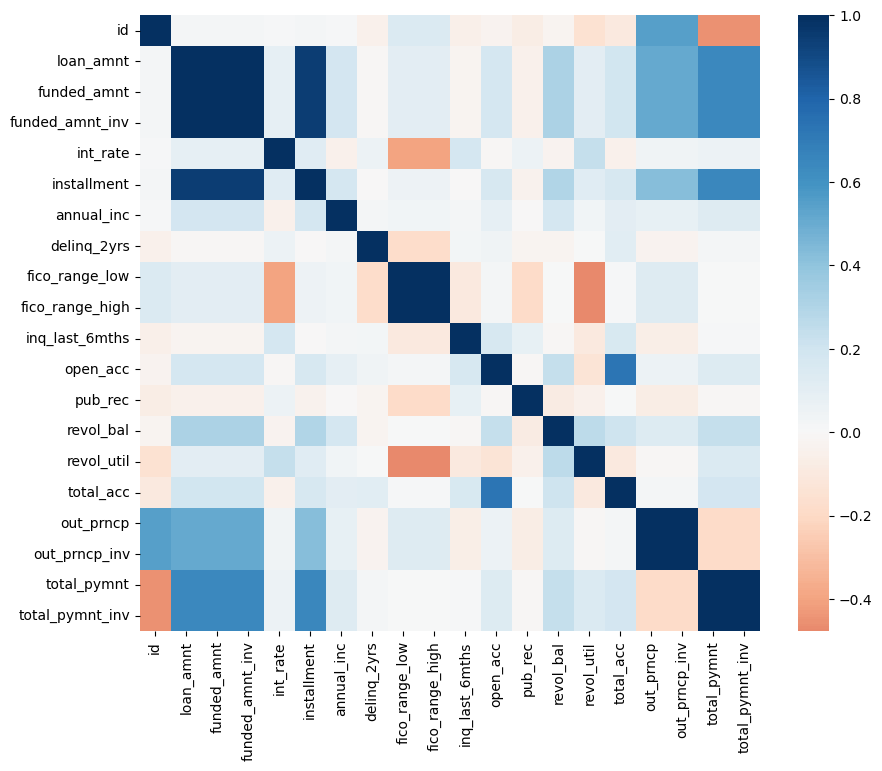

|  | id | loan_amnt | funded_amnt | funded_amnt_inv | int_rate | installment | annual_inc | delinq_2yrs | fico_range_low | fico_range_high |
| --- | --- | --- | --- | --- | --- | --- | --- | --- | --- | --- |
| id | 1.000000 | 0.024462 | 0.024463 | 0.024575 | 0.015360 | 0.024049 | 0.009002 | -0.050087 | 0.147450 | 0.147449 |
| loan_amnt | 0.024462 | 1.000000 | 0.999999 | 0.999994 | 0.088365 | 0.944868 | 0.183151 | -0.013256 | 0.110401 | 0.110400 |
| funded_amnt | 0.024463 | 0.999999 | 1.000000 | 0.999995 | 0.088366 | 0.944869 | 0.183151 | -0.013256 | 0.110401 | 0.110400 |
| funded_amnt_inv | 0.024575 | 0.999994 | 0.999995 | 1.000000 | 0.088353 | 0.944784 | 0.183159 | -0.013295 | 0.110527 | 0.110525 |
| int_rate | 0.015360 | 0.088365 | 0.088366 | 0.088353 | 1.000000 | 0.121838 | -0.050499 | 0.056159 | -0.396745 | -0.396741 |
| installment | 0.024049 | 0.944868 | 0.944869 | 0.944784 | 0.121838 | 1.000000 | 0.175801 | -0.001484 | 0.052747 | 0.052746 |
| annual_inc | 0.009002 | 0.183151 | 0.183151 | 0.183159 | -0.050499 | 0.175801 | 1.000000 | 0.023039 | 0.031080 | 0.031080 |
| delinq_2yrs | -0.050087 | -0.013256 | -0.013256 | -0.013295 | 0.056159 | -0.001484 | 0.023039 | 1.000000 | -0.179189 | -0.179186 |
| fico_range_low | 0.147450 | 0.110401 | 0.110401 | 0.110527 | -0.396745 | 0.052747 | 0.031080 | -0.179189 | 1.000000 | 1.000000 |
| fico_range_high | 0.147449 | 0.110400 | 0.110400 | 0.110525 | -0.396741 | 0.052746 | 0.031080 | -0.179186 | 1.000000 | 1.000000 |

```python
from pandas.api import types as ptypes
import matplotlib.pyplot as plt

# identify numeric columns
num_cols = [c for c in df_trimmed.columns if ptypes.is_numeric_dtype(df_trimmed[c].dtype)]
print("Numeric columns count:", len(num_cols))
print("Sample numeric cols:", num_cols[:40])

if len(num_cols) >= 2:
    # compute correlation matrix
    corr = df_trimmed[num_cols].corr()

    # save correlation matrix
    corr_file = os.path.join(eda_dir, "correlation_matrix_after_dtype.csv")
    corr.to_csv(corr_file)
    print("Saved correlation matrix to:", corr_file)

    # pick up to 20 numeric columns for a readable heatmap
    topN = min(20, len(num_cols))
    top_cols = num_cols[:topN]

    fig, ax = plt.subplots(figsize=(10, 8))
    sns.heatmap(df_trimmed[top_cols].corr(), annot=False, cmap="RdBu", center=0, ax=ax)

    # save heatmap
    heatmap_file = os.path.join(eda_dir, "corr_top20_heatmap.png")
    fig.savefig(heatmap_file, bbox_inches="tight")
    print("Saved heatmap to:", heatmap_file)

    # show heatmap in notebook
    plt.show()

    # show a preview of correlation table
    display(corr.iloc[:10, :10])

else:
    print("Not enough numeric columns to compute correlation.")
```

## EDA Step 5 — Histograms for numeric variables

### Why:

Histograms show the shape of each numeric variable—skewness, heavy tails, unusual spikes, and the effects of earlier cleaning.  
This helps identify variables that may require transformation in Notebook 03 (e.g., log transform, binning).

### How:

- Identify numeric columns after dtype conversion.
- Loop through them one by one.
- Make a simple matplotlib histogram.
- Save each plot as a PNG and also display it in the notebook.

```
Number of numeric columns: 73
```

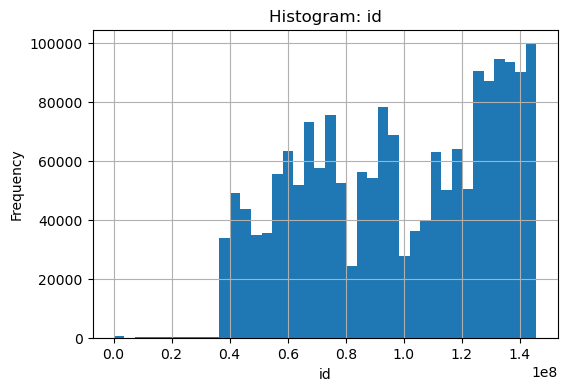

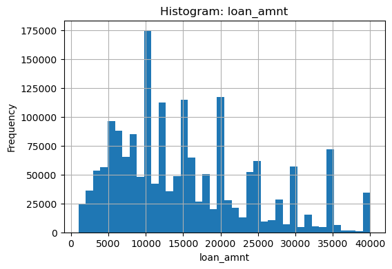

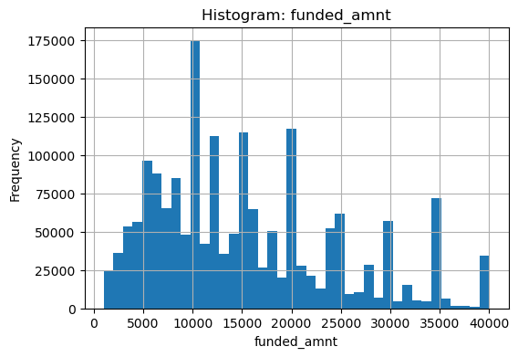

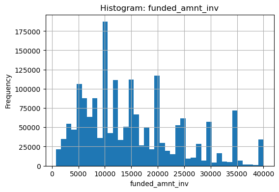

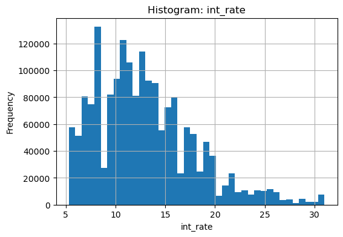

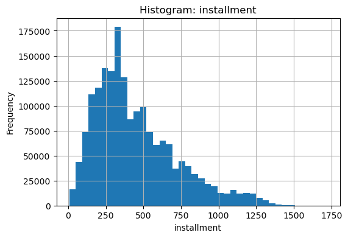

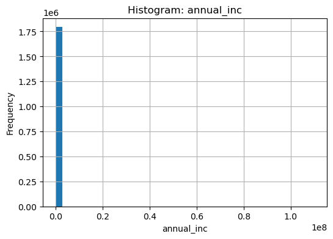

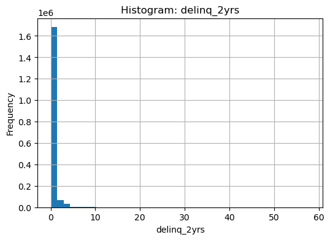

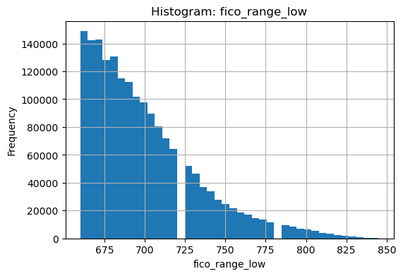

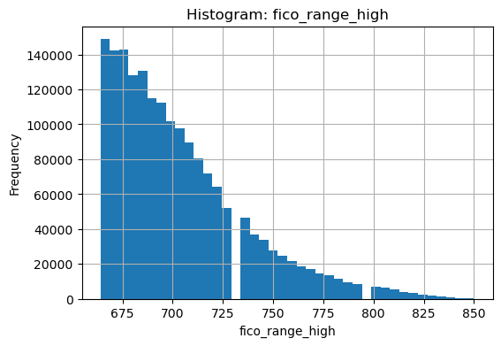

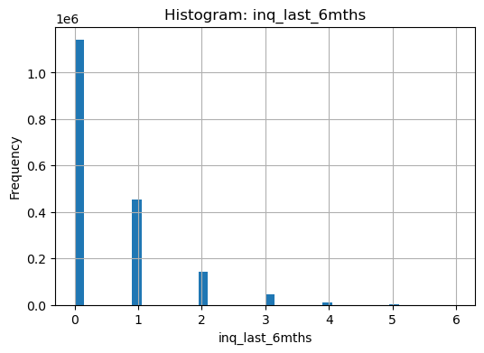

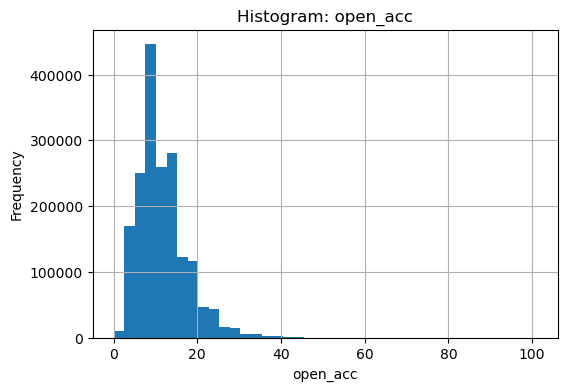

[61 more figures not shown]

```
Saved all histograms to: C:\Users\deves\Documents\GitHub\portfolio\pdpit-lendingclub\artifacts\notebook02_eda\histograms
```

```python
from pandas.api import types as ptypes
import matplotlib.pyplot as plt

# identify numeric columns
num_cols = [c for c in df_trimmed.columns if ptypes.is_numeric_dtype(df_trimmed[c].dtype)]

print("Number of numeric columns:", len(num_cols))

# folder for histogram images
hist_dir = os.path.join(eda_dir, "histograms")
os.makedirs(hist_dir, exist_ok=True)

for c in num_cols:
    plt.figure(figsize=(6,4))
    df_trimmed[c].hist(bins=40)
    plt.title(f"Histogram: {c}")
    plt.xlabel(c)
    plt.ylabel("Frequency")

    # save file
    fname = os.path.join(hist_dir, f"hist_{c}.png")
    plt.savefig(fname, bbox_inches="tight")

    # show plot
    plt.show()

print("Saved all histograms to:", hist_dir)
```

### Decision Notes:

- Histograms are not used for selection directly; they help visually diagnose skewness and decide transformations in Notebook 03.
- Features with extreme skewness may require log-transform or scaling later.
- All histogram PNGs are saved for validator inspection.

## EDA Step 6 — Boxplots (numeric variables)

### How:

- Use each numeric column individually (one plot per feature).
- Save each boxplot in the EDA artifacts folder.
- Display the plot inside the notebook.

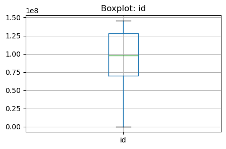

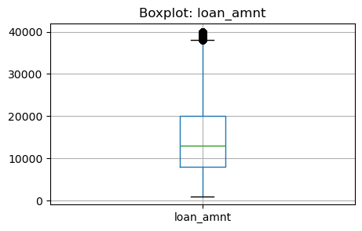

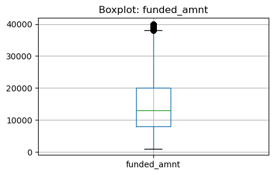

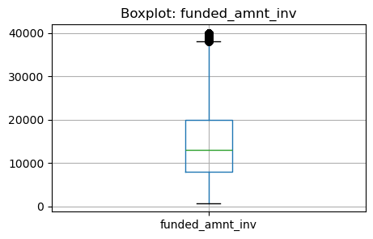

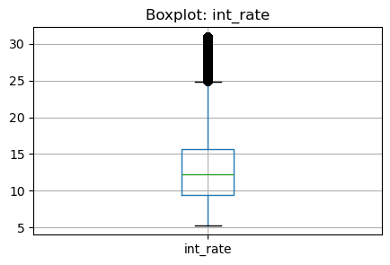

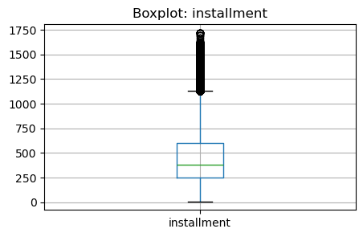

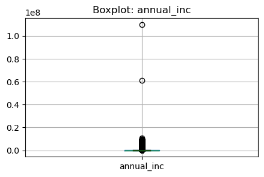

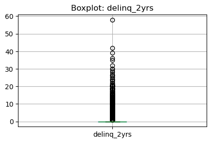

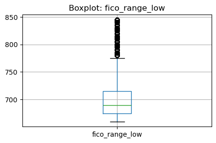

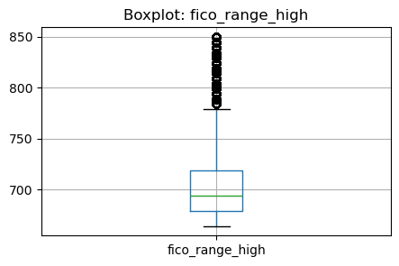

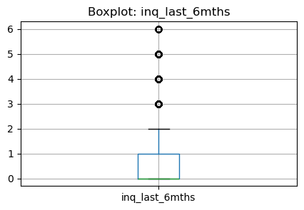

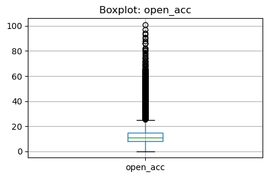

[61 more figures not shown]

```
Saved all boxplots to: C:\Users\deves\Documents\GitHub\portfolio\pdpit-lendingclub\artifacts\notebook02_eda\boxplots
```

```python
# folder for boxplots
box_dir = os.path.join(eda_dir, "boxplots")
os.makedirs(box_dir, exist_ok=True)

for c in num_cols:
    plt.figure(figsize=(5,3))
    df_trimmed.boxplot(column=c)
    plt.title(f"Boxplot: {c}")

    fname = os.path.join(box_dir, f"box_{c}.png")
    plt.savefig(fname, bbox_inches="tight")
    plt.show()

print("Saved all boxplots to:", box_dir)
```

## EDA Step 7 — Target variable distribution (`default_ind`)

### Why:

Understanding the ratio of good vs. bad loans is crucial before building a PD model.  
PD models are sensitive to class imbalance, and the distribution determines whether balancing techniques are required in Notebook 05.

### How:

- Simple value counts of `default_ind`.
- Compute class ratio.
- Save distribution as CSV.
- Display a bar plot showing class imbalance.

| default_ind | count | pct |
| --- | --- | --- |
| 0 | 1581094 | 0.881165 |
| 1 | 213229 | 0.118835 |

```
Saved target distribution to: C:\Users\deves\Documents\GitHub\portfolio\pdpit-lendingclub\artifacts\notebook02_eda\target_distribution.csv
```

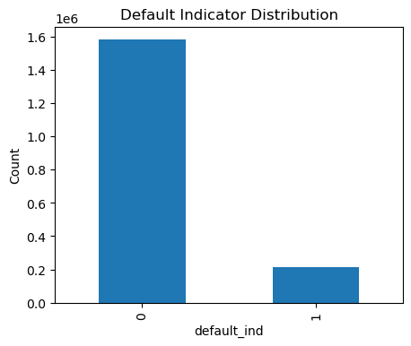

```python
# basic class distribution
target_counts = df_trimmed["default_ind"].value_counts(dropna=False)
target_pct = target_counts / len(df_trimmed)

target_df = pd.DataFrame({
    "count": target_counts,
    "pct": target_pct
})
display(target_df)

# save distribution
target_file = os.path.join(eda_dir, "target_distribution.csv")
target_df.to_csv(target_file)
print("Saved target distribution to:", target_file)

# bar plot
plt.figure(figsize=(5,4))
target_counts.plot(kind="bar")
plt.title("Default Indicator Distribution")
plt.xlabel("default_ind")
plt.ylabel("Count")

target_plot = os.path.join(eda_dir, "target_distribution_plot.png")
plt.savefig(target_plot, bbox_inches="tight")
plt.show()
```

### Decision Notes:

- This distribution will guide class-balancing decisions in Notebook 05.
- If imbalance is large (e.g., bad rate < 5%), we may consider class weighting or stratified sampling later.
- No modification to the dataset occurs at this step; this is purely diagnostic.

```python
# Save the cleaned + trimmed dataset for Notebook 03
save_path = r"C:\Users\deves\Documents\GitHub\portfolio\pdpit-lendingclub\data\processed\accepted_2015_to_2018_filtered.parquet"
df_trimmed.to_parquet(save_path, index=False)

print("Saved cleaned/trimmed dataset to:")
print(save_path)
print("Shape:", df_trimmed.shape)
```

```
Saved cleaned/trimmed dataset to:
C:\Users\deves\Documents\GitHub\portfolio\pdpit-lendingclub\data\processed\accepted_2015_to_2018_filtered.parquet
Shape: (1794323, 113)
```